# Import part 1

Import part 1 see also http://r4ds.had.co.nz/data-import.html

read.table() is the main function

- read.csv() = wrapper for CSV
- read.delim() = wrapper for tab-deliminated

read.table(“states.csv”, header = TRUE, sep = “,”, stringsAsFactors = FALSE) read.csv(“states.csv”, stringsAsFactors = FALSE)

read.table(“states.txt”, header = TRUE, sep = “”, stringsAsFactors = FALSE) read.delim(“states.txt”, stringsAsFactors = FALSE)

```r
library(utils)
pools <- read.csv("swimming_pools.csv", stringsAsFactors = FALSE)
str(pools)
```

```
'data.frame':   20 obs. of  4 variables:
 $ Name     : chr  "Acacia Ridge Leisure Centre" "Bellbowrie Pool" "Carole Park" "Centenary Pool (inner City)" ...
 $ Address  : chr  "1391 Beaudesert Road, Acacia Ridge" "Sugarwood Street, Bellbowrie" "Cnr Boundary Road and Waterford Road Wacol" "400 Gregory Terrace, Spring Hill" ...
 $ Latitude : num  -27.6 -27.6 -27.6 -27.5 -27.4 ...
 $ Longitude: num  153 153 153 153 153 ...
```

```r
# Import hotdogs.txt: hotdogs
hotdogs <- read.delim("hotdogs.txt", header = FALSE)
# Summarize hotdogs
summary(hotdogs)
```

```
       V1           V2              V3
 Beef   :20   Min.   : 86.0   Min.   :144.0
 Meat   :17   1st Qu.:132.0   1st Qu.:362.5
 Poultry:17   Median :145.0   Median :405.0
              Mean   :145.4   Mean   :424.8
              3rd Qu.:172.8   3rd Qu.:503.5
              Max.   :195.0   Max.   :645.0
```

read.table is superior: If you’re dealing with more exotic flat file formats, you’ll want to use read.table(). It’s the most basic importing function; you can specify tons of different arguments in this function. Unlike read.csv() and read.delim(), the header argument defaults to FALSE and the sep argument is “” by default.

read.table(file, header = FALSE, sep = “”, quote = “"’”, dec = “.”, numerals = c(“allow.loss”, “warn.loss”, “no.loss”), row.names, col.names, as.is = !stringsAsFactors, na.strings = “NA”, colClasses = NA, nrows = -1, skip = 0, check.names = TRUE, fill = !blank.lines.skip, strip.white = FALSE, blank.lines.skip = TRUE, comment.char = “#”, allowEscapes = FALSE, flush = FALSE, stringsAsFactors = default.stringsAsFactors(), fileEncoding = “”, encoding = “unknown”, text, skipNul = FALSE)

read.table

```r
# Path to the hotdogs.txt file: path
path <- file.path("data", "hotdogs.txt")
# Import the hotdogs.txt file: hotdogs
hotdogs <- read.table(path,
                      sep = "",
                      col.names = c("type", "calories", "sodium"))
# Call head() on hotdogs
head(hotdogs)
```

|  | type | calories | sodium |
| --- | --- | --- | --- |
| 1 | Beef | 186 | 495 |
| 2 | Beef | 181 | 477 |
| 3 | Beef | 176 | 425 |
| 4 | Beef | 149 | 322 |
| 5 | Beef | 184 | 482 |
| 6 | Beef | 190 | 587 |

Arguments

```r
# Finish the read.delim() call
hotdogs <- read.delim("hotdogs.txt", header = FALSE, col.names = c("type", "calories", "sodium"))
# Select the hot dog with the least calories: lily
lily <- hotdogs[which.min(hotdogs$calories), ]
# Select the observation with the most sodium: tom
tom <- hotdogs[which.max(hotdogs$sodium),]
# Print lily and tom
lily
```

|  | type | calories | sodium |
| --- | --- | --- | --- |
| 50 | Poultry | 86 | 358 |

```r
tom
```

|  | type | calories | sodium |
| --- | --- | --- | --- |
| 15 | Beef | 190 | 645 |

Column classes colClasses = c(“factor”, “NULL”, “numeric”) This approach can be useful if you have some columns that should be factors and others that should be characters. You don’t have to bother with stringsAsFactors anymore; just state for each column what the class should be

```r
# Previous call to import hotdogs.txt
hotdogs <- read.delim("hotdogs.txt", header = FALSE, col.names = c("type", "calories", "sodium"))
# Display structure of hotdogs
str(hotdogs)
```

```
'data.frame':   54 obs. of  3 variables:
 $ type    : Factor w/ 3 levels "Beef","Meat",..: 1 1 1 1 1 1 1 1 1 1 ...
 $ calories: int  186 181 176 149 184 190 158 139 175 148 ...
 $ sodium  : int  495 477 425 322 482 587 370 322 479 375 ...
```

```r
# Edit the colClasses argument to import the data correctly: hotdogs2
hotdogs2 <- read.delim("hotdogs.txt", header = FALSE,
                       col.names = c("type", "calories", "sodium"),
                       colClasses = c("factor", "NULL", "numeric")
)
# Display structure of hotdogs2
str(hotdogs2)
```

```
'data.frame':   54 obs. of  2 variables:
 $ type  : Factor w/ 3 levels "Beef","Meat",..: 1 1 1 1 1 1 1 1 1 1 ...
 $ sodium: num  495 477 425 322 482 587 370 322 479 375 ...
```

### package: readr

see https://github.com/tidyverse/readr

- read.table {utils}
- read_csv {readr} reads into a tibble
- read_tsv {readr}
- read_csv and read_tsv = wrappers for read_cvs

read_csv

```r
potatoes <- read_csv("potatoes.csv")
```

read_tsv

```r
# Column names
properties <- c("area", "temp", "size", "storage", "method",
                "texture", "flavor", "moistness")
# Import potatoes.txt: potatoes
potatoes <- read_tsv("potatoes.txt", col_names = properties)
# Call head() on potatoes
head(potatoes)
```

| area | temp | size | storage | method | texture | flavor | moistness |
| --- | --- | --- | --- | --- | --- | --- | --- |
| 1 | 1 | 1 | 1 | 1 | 2.9 | 3.2 | 3.0 |
| 1 | 1 | 1 | 1 | 2 | 2.3 | 2.5 | 2.6 |
| 1 | 1 | 1 | 1 | 3 | 2.5 | 2.8 | 2.8 |
| 1 | 1 | 1 | 1 | 4 | 2.1 | 2.9 | 2.4 |
| 1 | 1 | 1 | 1 | 5 | 1.9 | 2.8 | 2.2 |
| 1 | 1 | 1 | 2 | 1 | 1.8 | 3.0 | 1.7 |

- file
- delim

```r
# readr is already loaded
# Column names
properties <- c("area", "temp", "size", "storage", "method",
                "texture", "flavor", "moistness")
# Import potatoes.txt using read_delim(): potatoes
potatoes <- read_delim("potatoes.txt", col_names = properties, delim = "\t")
# Print out potatoes
potatoes
```

| area | temp | size | storage | method | texture | flavor | moistness |
| --- | --- | --- | --- | --- | --- | --- | --- |
| 1 | 1 | 1 | 1 | 1 | 2.9 | 3.2 | 3.0 |
| 1 | 1 | 1 | 1 | 2 | 2.3 | 2.5 | 2.6 |
| 1 | 1 | 1 | 1 | 3 | 2.5 | 2.8 | 2.8 |
| 1 | 1 | 1 | 1 | 4 | 2.1 | 2.9 | 2.4 |
| 1 | 1 | 1 | 1 | 5 | 1.9 | 2.8 | 2.2 |
| 1 | 1 | 1 | 2 | 1 | 1.8 | 3.0 | 1.7 |
| 1 | 1 | 1 | 2 | 2 | 2.6 | 3.1 | 2.4 |
| 1 | 1 | 1 | 2 | 3 | 3.0 | 3.0 | 2.9 |
| 1 | 1 | 1 | 2 | 4 | 2.2 | 3.2 | 2.5 |
| 1 | 1 | 1 | 2 | 5 | 2.0 | 2.8 | 1.9 |

[output cut: 150 more lines]

col_types

```r
# readr is already loaded
# Column names
properties <- c("area", "temp", "size", "storage", "method",
                "texture", "flavor", "moistness")
# Import all data, but force all columns to be character: potatoes_char
potatoes_char <- read_tsv("potatoes.txt", col_types = "cccccccc", col_names = properties)
# Print out structure of potatoes_char
str(potatoes_char)
```

```
Classes âtbl_dfâ, âtblâ and 'data.frame':   160 obs. of  8 variables:
 $ area     : chr  "1" "1" "1" "1" ...
 $ temp     : chr  "1" "1" "1" "1" ...
 $ size     : chr  "1" "1" "1" "1" ...
 $ storage  : chr  "1" "1" "1" "1" ...
 $ method   : chr  "1" "2" "3" "4" ...
 $ texture  : chr  "2.9" "2.3" "2.5" "2.1" ...
 $ flavor   : chr  "3.2" "2.5" "2.8" "2.9" ...
 $ moistness: chr  "3.0" "2.6" "2.8" "2.4" ...
 - attr(*, "spec")=List of 2
  ..$ cols   :List of 8
  .. ..$ area     : list()
  .. .. ..- attr(*, "class")= chr  "collector_character" "collector"
  .. ..$ temp     : list()
  .. .. ..- attr(*, "class")= chr  "collector_character" "collector"
  .. ..$ size     : list()
  .. .. ..- attr(*, "class")= chr  "collector_character" "collector"
  .. ..$ storage  : list()
  .. .. ..- attr(*, "class")= chr  "collector_character" "collector"
  .. ..$ method   : list()
  .. .. ..- attr(*, "class")= chr  "collector_character" "collector"
  .. ..$ texture  : list()
  .. .. ..- attr(*, "class")= chr  "collector_character" "collector"
  .. ..$ flavor   : list()
  .. .. ..- attr(*, "class")= chr  "collector_character" "collector"
  .. ..$ moistness: list()
  .. .. ..- attr(*, "class")= chr  "collector_character" "collector"
  ..$ default: list()
  .. ..- attr(*, "class")= chr  "collector_guess" "collector"
  ..- attr(*, "class")= chr "col_spec"
```

col_types with collector function

Another way of setting the types of the imported columns is using collectors. Collector functions can be passed in a list() to the col_types argument of read_ functions to tell them how to interpret values in a column.

For a complete list of collector functions, you can take a look at the collector documentation. For this exercise you will need two collector functions:

- col_integer(): the column should be interpreted as an integer.
- col_factor(levels, ordered = FALSE): the column should be interpreted as a factor with levels.

In this exercise, you will work with hotdogs.txt, which is a tab-delimited file without column names in the first row.

```r
# readr is already loaded
# Import without col_types
hotdogs <- read_tsv("hotdogs.txt", col_names = c("type", "calories", "sodium"))
# Display the summary of hotdogs
summary(hotdogs)
```

```
     type              calories         sodium
 Length:54          Min.   : 86.0   Min.   :144.0
 Class :character   1st Qu.:132.0   1st Qu.:362.5
 Mode  :character   Median :145.0   Median :405.0
                    Mean   :145.4   Mean   :424.8
                    3rd Qu.:172.8   3rd Qu.:503.5
                    Max.   :195.0   Max.   :645.0
```

```r
# The collectors you will need to import the data
fac <- col_factor(levels = c("Beef", "Meat", "Poultry"))
int <- col_integer()
# Edit the col_types argument to import the data correctly: hotdogs_factor
hotdogs_factor <- read_tsv("hotdogs.txt",
                           col_names = c("type", "calories", "sodium"),
                           col_types = list(fac,int,int))
# Display the summary of hotdogs_factor
summary(hotdogs_factor)
```

```
      type       calories         sodium
 Beef   :20   Min.   : 86.0   Min.   :144.0
 Meat   :17   1st Qu.:132.0   1st Qu.:362.5
 Poultry:17   Median :145.0   Median :405.0
              Mean   :145.4   Mean   :424.8
              3rd Qu.:172.8   3rd Qu.:503.5
              Max.   :195.0   Max.   :645.0
```

fread

```r
library(data.table)
```

fread: more advanced use

Now that you know the basics about fread(), you should know about two arguments of the function: drop and select, to drop or select variables of interest.

Suppose you have a dataset that contains 5 variables and you want to keep the first and fifth variable, named “a” and “e”. The following options will all do the trick:

fread(“path/to/file.txt”, drop = 2:4) fread(“path/to/file.txt”, select = c(1, 5)) fread(“path/to/file.txt”, drop = c(“b”, “c”, “d”) fread(“path/to/file.txt”, select = c(“a”, “e”))

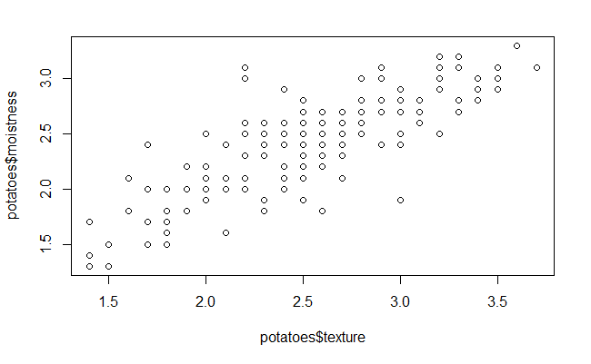

```r
# fread is already loaded
# Import columns 6 and 8 of potatoes.csv: potatoes
potatoes <- fread("potatoes.csv", select = c(6,8))
# Plot texture (x) and moistness (y) of potatoes
plot(potatoes$texture, potatoes$moistness)
```

```r
class(dpot); class(rpot); class(tpot)
```

```
[1] "data.frame"
[1] "data.table" "data.frame"
[1] "tbl_df"     "tbl"        "data.frame"
```

Importing Excel data

List the sheets of an Excel file

```r
# Load the readxl package
library(readxl)
# Print out the names of both spreadsheets
excel_sheets("urbanpop.xlsx")
```

```
[1] "1960-1966" "1967-1974" "1975-2011"
```

mine

```r
excel_sheets(path)
```

```
[1] "TOC"                 "T1.10-RAPM"          "T1.10-RAPM Practice" "T1.10-Sortino"
[5] "T1.404.1"            "T1.404.2"            "T1.404.3"
```

import an excel sheet

```r
# The readxl package is already loaded
# Read the sheets, one by one
pop_1 <- read_excel("urbanpop.xlsx", sheet = 1)
pop_2 <- read_excel("urbanpop.xlsx", sheet = 2)
pop_3 <- read_excel("urbanpop.xlsx", sheet = 3)
# Put pop_1, pop_2 and pop_3 in a list: pop_list
pop_list <- list(pop_1, pop_2, pop_3)
# Display the structure of pop_list
str(pop_list)
```

```
List of 3
 $ :Classes âtbl_dfâ, âtblâ and 'data.frame':   209 obs. of  8 variables:
  ..$ country: chr [1:209] "Afghanistan" "Albania" "Algeria" "American Samoa" ...
  ..$ 1960   : num [1:209] 769308 494443 3293999 NA NA ...
  ..$ 1961   : num [1:209] 814923 511803 3515148 13660 8724 ...
  ..$ 1962   : num [1:209] 858522 529439 3739963 14166 9700 ...
  ..$ 1963   : num [1:209] 903914 547377 3973289 14759 10748 ...
  ..$ 1964   : num [1:209] 951226 565572 4220987 15396 11866 ...
  ..$ 1965   : num [1:209] 1000582 583983 4488176 16045 13053 ...
  ..$ 1966   : num [1:209] 1058743 602512 4649105 16693 14217 ...
 $ :Classes âtbl_dfâ, âtblâ and 'data.frame':   209 obs. of  9 variables:
  ..$ country: chr [1:209] "Afghanistan" "Albania" "Algeria" "American Samoa" ...
  ..$ 1967   : num [1:209] 1119067 621180 4826104 17349 15440 ...
  ..$ 1968   : num [1:209] 1182159 639964 5017299 17996 16727 ...
  ..$ 1969   : num [1:209] 1248901 658853 5219332 18619 18088 ...
  ..$ 1970   : num [1:209] 1319849 677839 5429743 19206 19529 ...
  ..$ 1971   : num [1:209] 1409001 698932 5619042 19752 20929 ...
  ..$ 1972   : num [1:209] 1502402 720207 5815734 20263 22406 ...
  ..$ 1973   : num [1:209] 1598835 741681 6020647 20742 23937 ...
  ..$ 1974   : num [1:209] 1696445 763385 6235114 21194 25482 ...
 $ :Classes âtbl_dfâ, âtblâ and 'data.frame':   209 obs. of  38 variables:
  ..$ country: chr [1:209] "Afghanistan" "Albania" "Algeria" "American Samoa" ...
  ..$ 1975   : num [1:209] 1793266 785350 6460138 21632 27019 ...
  ..$ 1976   : num [1:209] 1905033 807990 6774099 22047 28366 ...
  ..$ 1977   : num [1:209] 2021308 830959 7102902 22452 29677 ...
  ..$ 1978   : num [1:209] 2142248 854262 7447728 22899 31037 ...
  ..$ 1979   : num [1:209] 2268015 877898 7810073 23457 32572 ...
  ..$ 1980   : num [1:209] 2398775 901884 8190772 24177 34366 ...
  ..$ 1981   : num [1:209] 2493265 927224 8637724 25173 36356 ...
  ..$ 1982   : num [1:209] 2590846 952447 9105820 26342 38618 ...
  ..$ 1983   : num [1:209] 2691612 978476 9591900 27655 40983 ...
  ..$ 1984   : num [1:209] 2795656 1006613 10091289 29062 43207 ...
  ..$ 1985   : num [1:209] 2903078 1037541 10600112 30524 45119 ...
  ..$ 1986   : num [1:209] 3006983 1072365 11101757 32014 46254 ...
  ..$ 1987   : num [1:209] 3113957 1109954 11609104 33548 47019 ...
  ..$ 1988   : num [1:209] 3224082 1146633 12122941 35095 47669 ...
  ..$ 1989   : num [1:209] 3337444 1177286 12645263 36618 48577 ...
  ..$ 1990   : num [1:209] 3454129 1198293 13177079 38088 49982 ...
  ..$ 1991   : num [1:209] 3617842 1215445 13708813 39600 51972 ...
  ..$ 1992   : num [1:209] 3788685 1222544 14248297 41049 54469 ...
  ..$ 1993   : num [1:209] 3966956 1222812 14789176 42443 57079 ...
  ..$ 1994   : num [1:209] 4152960 1221364 15322651 43798 59243 ...
  ..$ 1995   : num [1:209] 4347018 1222234 15842442 45129 60598 ...
  ..$ 1996   : num [1:209] 4531285 1228760 16395553 46343 60927 ...
  ..$ 1997   : num [1:209] 4722603 1238090 16935451 47527 60462 ...
  ..$ 1998   : num [1:209] 4921227 1250366 17469200 48705 59685 ...
  ..$ 1999   : num [1:209] 5127421 1265195 18007937 49906 59281 ...
  ..$ 2000   : num [1:209] 5341456 1282223 18560597 51151 59719 ...
  ..$ 2001   : num [1:209] 5564492 1315690 19198872 52341 61062 ...
  ..$ 2002   : num [1:209] 5795940 1352278 19854835 53583 63212 ...
  ..$ 2003   : num [1:209] 6036100 1391143 20529356 54864 65802 ...
  ..$ 2004   : num [1:209] 6285281 1430918 21222198 56166 68301 ...
  ..$ 2005   : num [1:209] 6543804 1470488 21932978 57474 70329 ...
  ..$ 2006   : num [1:209] 6812538 1512255 22625052 58679 71726 ...
  ..$ 2007   : num [1:209] 7091245 1553491 23335543 59894 72684 ...
  ..$ 2008   : num [1:209] 7380272 1594351 24061749 61118 73335 ...
  ..$ 2009   : num [1:209] 7679982 1635262 24799591 62357 73897 ...
  ..$ 2010   : num [1:209] 7990746 1676545 25545622 63616 74525 ...
  ..$ 2011   : num [1:209] 8316976 1716842 26216968 64817 75207 ...
```

Reading a workbook my_workbook <- lapply(excel_sheets(“data.xlsx”), read_excel, path = “data.xlsx”)

```r
# The readxl package is already loaded
# Read all Excel sheets with lapply(): pop_list
pop_list <- lapply(excel_sheets("urbanpop.xlsx"), read_excel, path = "urbanpop.xlsx")
# pop_list <- lapply(excel_sheets("urbanpop.xlsx"), read_excel) won't work returns:
# Error: '1960-1966' does not exist in current working directory ('D:/GitHub/dc/import-p1').
# Display the structure of pop_list
str(pop_list)
```

```
List of 3
 $ :Classes âtbl_dfâ, âtblâ and 'data.frame':   209 obs. of  8 variables:
  ..$ country: chr [1:209] "Afghanistan" "Albania" "Algeria" "American Samoa" ...
  ..$ 1960   : num [1:209] 769308 494443 3293999 NA NA ...
  ..$ 1961   : num [1:209] 814923 511803 3515148 13660 8724 ...
  ..$ 1962   : num [1:209] 858522 529439 3739963 14166 9700 ...
  ..$ 1963   : num [1:209] 903914 547377 3973289 14759 10748 ...
  ..$ 1964   : num [1:209] 951226 565572 4220987 15396 11866 ...
  ..$ 1965   : num [1:209] 1000582 583983 4488176 16045 13053 ...
  ..$ 1966   : num [1:209] 1058743 602512 4649105 16693 14217 ...
 $ :Classes âtbl_dfâ, âtblâ and 'data.frame':   209 obs. of  9 variables:
  ..$ country: chr [1:209] "Afghanistan" "Albania" "Algeria" "American Samoa" ...
  ..$ 1967   : num [1:209] 1119067 621180 4826104 17349 15440 ...
  ..$ 1968   : num [1:209] 1182159 639964 5017299 17996 16727 ...
  ..$ 1969   : num [1:209] 1248901 658853 5219332 18619 18088 ...
  ..$ 1970   : num [1:209] 1319849 677839 5429743 19206 19529 ...
  ..$ 1971   : num [1:209] 1409001 698932 5619042 19752 20929 ...
  ..$ 1972   : num [1:209] 1502402 720207 5815734 20263 22406 ...
  ..$ 1973   : num [1:209] 1598835 741681 6020647 20742 23937 ...
  ..$ 1974   : num [1:209] 1696445 763385 6235114 21194 25482 ...
 $ :Classes âtbl_dfâ, âtblâ and 'data.frame':   209 obs. of  38 variables:
  ..$ country: chr [1:209] "Afghanistan" "Albania" "Algeria" "American Samoa" ...
  ..$ 1975   : num [1:209] 1793266 785350 6460138 21632 27019 ...
  ..$ 1976   : num [1:209] 1905033 807990 6774099 22047 28366 ...
  ..$ 1977   : num [1:209] 2021308 830959 7102902 22452 29677 ...
  ..$ 1978   : num [1:209] 2142248 854262 7447728 22899 31037 ...
  ..$ 1979   : num [1:209] 2268015 877898 7810073 23457 32572 ...
  ..$ 1980   : num [1:209] 2398775 901884 8190772 24177 34366 ...
  ..$ 1981   : num [1:209] 2493265 927224 8637724 25173 36356 ...
  ..$ 1982   : num [1:209] 2590846 952447 9105820 26342 38618 ...
  ..$ 1983   : num [1:209] 2691612 978476 9591900 27655 40983 ...
  ..$ 1984   : num [1:209] 2795656 1006613 10091289 29062 43207 ...
  ..$ 1985   : num [1:209] 2903078 1037541 10600112 30524 45119 ...
  ..$ 1986   : num [1:209] 3006983 1072365 11101757 32014 46254 ...
  ..$ 1987   : num [1:209] 3113957 1109954 11609104 33548 47019 ...
  ..$ 1988   : num [1:209] 3224082 1146633 12122941 35095 47669 ...
  ..$ 1989   : num [1:209] 3337444 1177286 12645263 36618 48577 ...
  ..$ 1990   : num [1:209] 3454129 1198293 13177079 38088 49982 ...
  ..$ 1991   : num [1:209] 3617842 1215445 13708813 39600 51972 ...
  ..$ 1992   : num [1:209] 3788685 1222544 14248297 41049 54469 ...
  ..$ 1993   : num [1:209] 3966956 1222812 14789176 42443 57079 ...
  ..$ 1994   : num [1:209] 4152960 1221364 15322651 43798 59243 ...
  ..$ 1995   : num [1:209] 4347018 1222234 15842442 45129 60598 ...
  ..$ 1996   : num [1:209] 4531285 1228760 16395553 46343 60927 ...
  ..$ 1997   : num [1:209] 4722603 1238090 16935451 47527 60462 ...
  ..$ 1998   : num [1:209] 4921227 1250366 17469200 48705 59685 ...
  ..$ 1999   : num [1:209] 5127421 1265195 18007937 49906 59281 ...
  ..$ 2000   : num [1:209] 5341456 1282223 18560597 51151 59719 ...
  ..$ 2001   : num [1:209] 5564492 1315690 19198872 52341 61062 ...
  ..$ 2002   : num [1:209] 5795940 1352278 19854835 53583 63212 ...
  ..$ 2003   : num [1:209] 6036100 1391143 20529356 54864 65802 ...
  ..$ 2004   : num [1:209] 6285281 1430918 21222198 56166 68301 ...
  ..$ 2005   : num [1:209] 6543804 1470488 21932978 57474 70329 ...
  ..$ 2006   : num [1:209] 6812538 1512255 22625052 58679 71726 ...
  ..$ 2007   : num [1:209] 7091245 1553491 23335543 59894 72684 ...
  ..$ 2008   : num [1:209] 7380272 1594351 24061749 61118 73335 ...
  ..$ 2009   : num [1:209] 7679982 1635262 24799591 62357 73897 ...
  ..$ 2010   : num [1:209] 7990746 1676545 25545622 63616 74525 ...
  ..$ 2011   : num [1:209] 8316976 1716842 26216968 64817 75207 ...
```

The col_names argument

```r
# The readxl package is already loaded
# Import the the first Excel sheet of urbanpop_nonames.xlsx (R gives names): pop_a
pop_a <- read_excel("urbanpop_nonames.xlsx", sheet = 1, col_names = FALSE)
# Import the the first Excel sheet of urbanpop_nonames.xlsx (specify col_names): pop_b
cols <- c("country", paste0("year_", 1960:1966))
pop_b <- read_excel("urbanpop_nonames.xlsx", sheet = 1, col_names = cols)
# Print the summary of pop_a
summary(pop_a)
```

```
      X0                  X1                  X2                  X3                  X4
 Length:209         Min.   :     3378   Min.   :     1028   Min.   :     1090   Min.   :     1154
 Class :character   1st Qu.:    88978   1st Qu.:    70644   1st Qu.:    74974   1st Qu.:    81870
 Mode  :character   Median :   580675   Median :   570159   Median :   593968   Median :   619331
                    Mean   :  4988124   Mean   :  4991613   Mean   :  5141592   Mean   :  5303711
                    3rd Qu.:  3077228   3rd Qu.:  2807280   3rd Qu.:  2948396   3rd Qu.:  3148941
                    Max.   :126469700   Max.   :129268133   Max.   :131974143   Max.   :134599886
                    NA's   :11
       X5                  X6                  X7
 Min.   :     1218   Min.   :     1281   Min.   :     1349
 1st Qu.:    84953   1st Qu.:    88633   1st Qu.:    93638
 Median :   645262   Median :   679109   Median :   735139
 Mean   :  5468966   Mean   :  5637394   Mean   :  5790281
 3rd Qu.:  3296444   3rd Qu.:  3317422   3rd Qu.:  3418036
 Max.   :137205240   Max.   :139663053   Max.   :141962708
```

```r
# Print the summary of pop_b
summary(pop_b)
```

```
   country            year_1960           year_1961           year_1962           year_1963
 Length:209         Min.   :     3378   Min.   :     1028   Min.   :     1090   Min.   :     1154
 Class :character   1st Qu.:    88978   1st Qu.:    70644   1st Qu.:    74974   1st Qu.:    81870
 Mode  :character   Median :   580675   Median :   570159   Median :   593968   Median :   619331
                    Mean   :  4988124   Mean   :  4991613   Mean   :  5141592   Mean   :  5303711
                    3rd Qu.:  3077228   3rd Qu.:  2807280   3rd Qu.:  2948396   3rd Qu.:  3148941
                    Max.   :126469700   Max.   :129268133   Max.   :131974143   Max.   :134599886
                    NA's   :11
   year_1964           year_1965           year_1966
 Min.   :     1218   Min.   :     1281   Min.   :     1349
 1st Qu.:    84953   1st Qu.:    88633   1st Qu.:    93638
 Median :   645262   Median :   679109   Median :   735139
 Mean   :  5468966   Mean   :  5637394   Mean   :  5790281
 3rd Qu.:  3296444   3rd Qu.:  3317422   3rd Qu.:  3418036
 Max.   :137205240   Max.   :139663053   Max.   :141962708
```

skip argument

```r
# The readxl package is already loaded
# Import the second sheet of urbanpop.xlsx, skipping the first 21 rows: urbanpop_sel
urbanpop_sel <- read_excel("urbanpop.xlsx", sheet = 2, col_names = FALSE, skip = 21)
# Print out the first observation from urbanpop_sel
head(urbanpop_sel,1)
```

| X0 | X1 | X2 | X3 | X4 | X5 | X6 | X7 | X8 |
| --- | --- | --- | --- | --- | --- | --- | --- | --- |
| Benin | 382022.1 | 411859.5 | 443013.1 | 475611.4 | 515819.5 | 557937.6 | 602093.2 | 648409.7 |

# gdata skipped

XLConnect

```r
# install.packages("XLConnect",destdir = "D:/rstats/library/")
# urbanpop.xlsx is available in your working directory
# Load the XLConnect package
library(XLConnect)
# Build connection to urbanpop.xlsx: my_book
my_book <- loadWorkbook("urbanpop.xlsx")
# Print out the class of my_book
class(my_book)
```

```
[1] "workbook"
attr(,"package")
[1] "XLConnect"
```

List and read Excel sheets

```r
# XLConnect is already available
# Build connection to urbanpop.xlsx
my_book <- loadWorkbook("urbanpop.xlsx")
# List the sheets in my_book
getSheets(my_book)
```

```
[1] "1960-1966" "1967-1974" "1975-2011"
```

```r
# Import the second sheet in my_book
(readWorksheet(my_book,2))
```

| country | X1967 | X1968 | X1969 | X1970 | X1971 | X1972 | X1973 | X1974 |
| --- | --- | --- | --- | --- | --- | --- | --- | --- |
| Afghanistan | 1.119067e+06 | 1.182159e+06 | 1.248901e+06 | 1.319849e+06 | 1.409001e+06 | 1.502402e+06 | 1.598835e+06 | 1.696445e+06 |
| Albania | 6.211798e+05 | 6.399645e+05 | 6.588531e+05 | 6.778391e+05 | 6.989322e+05 | 7.202066e+05 | 7.416810e+05 | 7.633855e+05 |
| Algeria | 4.826104e+06 | 5.017299e+06 | 5.219332e+06 | 5.429743e+06 | 5.619042e+06 | 5.815734e+06 | 6.020647e+06 | 6.235114e+06 |
| American Samoa | 1.734866e+04 | 1.799551e+04 | 1.861868e+04 | 1.920639e+04 | 1.975202e+04 | 2.026267e+04 | 2.074197e+04 | 2.119438e+04 |
| Andorra | 1.543962e+04 | 1.672699e+04 | 1.808832e+04 | 1.952896e+04 | 2.092873e+04 | 2.240584e+04 | 2.393705e+04 | 2.548198e+04 |
| Angola | 7.574963e+05 | 7.984593e+05 | 8.412620e+05 | 8.864016e+05 | 9.550101e+05 | 1.027397e+06 | 1.103830e+06 | 1.184486e+06 |
| Antigua and Barbuda | 2.208625e+04 | 2.214939e+04 | 2.218292e+04 | 2.218087e+04 | 2.256087e+04 | 2.290776e+04 | 2.322129e+04 | 2.350292e+04 |
| Argentina | 1.775328e+07 | 1.812410e+07 | 1.851046e+07 | 1.891807e+07 | 1.932972e+07 | 1.976308e+07 | 2.021142e+07 | 2.066473e+07 |
| Armenia | 1.337032e+06 | 1.392892e+06 | 1.449641e+06 | 1.507620e+06 | 1.564368e+06 | 1.622104e+06 | 1.680498e+06 | 1.739063e+06 |
| Aruba | 2.941472e+04 | 2.957609e+04 | 2.973787e+04 | 2.990157e+04 | 3.008136e+04 | 3.027976e+04 | 3.046742e+04 | 3.060287e+04 |

[output cut: 199 more lines]

```r
my_book <- loadWorkbook("urbanpop.xlsx")
sheets <- getSheets(my_book)
all <- lapply(sheets, readWorksheet, object = my_book)
str(all)
```

```
List of 3
 $ :'data.frame':   209 obs. of  8 variables:
  ..$ country: chr [1:209] "Afghanistan" "Albania" "Algeria" "American Samoa" ...
  ..$ X1960  : num [1:209] 769308 494443 3293999 NA NA ...
  ..$ X1961  : num [1:209] 814923 511803 3515148 13660 8724 ...
  ..$ X1962  : num [1:209] 858522 529439 3739963 14166 9700 ...
  ..$ X1963  : num [1:209] 903914 547377 3973289 14759 10748 ...
  ..$ X1964  : num [1:209] 951226 565572 4220987 15396 11866 ...
  ..$ X1965  : num [1:209] 1000582 583983 4488176 16045 13053 ...
  ..$ X1966  : num [1:209] 1058743 602512 4649105 16693 14217 ...
 $ :'data.frame':   209 obs. of  9 variables:
  ..$ country: chr [1:209] "Afghanistan" "Albania" "Algeria" "American Samoa" ...
  ..$ X1967  : num [1:209] 1119067 621180 4826104 17349 15440 ...
  ..$ X1968  : num [1:209] 1182159 639964 5017299 17996 16727 ...
  ..$ X1969  : num [1:209] 1248901 658853 5219332 18619 18088 ...
  ..$ X1970  : num [1:209] 1319849 677839 5429743 19206 19529 ...
  ..$ X1971  : num [1:209] 1409001 698932 5619042 19752 20929 ...
  ..$ X1972  : num [1:209] 1502402 720207 5815734 20263 22406 ...
  ..$ X1973  : num [1:209] 1598835 741681 6020647 20742 23937 ...
  ..$ X1974  : num [1:209] 1696445 763385 6235114 21194 25482 ...
 $ :'data.frame':   209 obs. of  38 variables:
  ..$ country: chr [1:209] "Afghanistan" "Albania" "Algeria" "American Samoa" ...
  ..$ X1975  : num [1:209] 1793266 785350 6460138 21632 27019 ...
  ..$ X1976  : num [1:209] 1905033 807990 6774099 22047 28366 ...
  ..$ X1977  : num [1:209] 2021308 830959 7102902 22452 29677 ...
  ..$ X1978  : num [1:209] 2142248 854262 7447728 22899 31037 ...
  ..$ X1979  : num [1:209] 2268015 877898 7810073 23457 32572 ...
  ..$ X1980  : num [1:209] 2398775 901884 8190772 24177 34366 ...
  ..$ X1981  : num [1:209] 2493265 927224 8637724 25173 36356 ...
  ..$ X1982  : num [1:209] 2590846 952447 9105820 26342 38618 ...
  ..$ X1983  : num [1:209] 2691612 978476 9591900 27655 40983 ...
  ..$ X1984  : num [1:209] 2795656 1006613 10091289 29062 43207 ...
  ..$ X1985  : num [1:209] 2903078 1037541 10600112 30524 45119 ...
  ..$ X1986  : num [1:209] 3006983 1072365 11101757 32014 46254 ...
  ..$ X1987  : num [1:209] 3113957 1109954 11609104 33548 47019 ...
  ..$ X1988  : num [1:209] 3224082 1146633 12122941 35095 47669 ...
  ..$ X1989  : num [1:209] 3337444 1177286 12645263 36618 48577 ...
  ..$ X1990  : num [1:209] 3454129 1198293 13177079 38088 49982 ...
  ..$ X1991  : num [1:209] 3617842 1215445 13708813 39600 51972 ...
  ..$ X1992  : num [1:209] 3788685 1222544 14248297 41049 54469 ...
  ..$ X1993  : num [1:209] 3966956 1222812 14789176 42443 57079 ...
  ..$ X1994  : num [1:209] 4152960 1221364 15322651 43798 59243 ...
  ..$ X1995  : num [1:209] 4347018 1222234 15842442 45129 60598 ...
  ..$ X1996  : num [1:209] 4531285 1228760 16395553 46343 60927 ...
  ..$ X1997  : num [1:209] 4722603 1238090 16935451 47527 60462 ...
  ..$ X1998  : num [1:209] 4921227 1250366 17469200 48705 59685 ...
  ..$ X1999  : num [1:209] 5127421 1265195 18007937 49906 59281 ...
  ..$ X2000  : num [1:209] 5341456 1282223 18560597 51151 59719 ...
  ..$ X2001  : num [1:209] 5564492 1315690 19198872 52341 61062 ...
  ..$ X2002  : num [1:209] 5795940 1352278 19854835 53583 63212 ...
  ..$ X2003  : num [1:209] 6036100 1391143 20529356 54864 65802 ...
  ..$ X2004  : num [1:209] 6285281 1430918 21222198 56166 68301 ...
  ..$ X2005  : num [1:209] 6543804 1470488 21932978 57474 70329 ...
  ..$ X2006  : num [1:209] 6812538 1512255 22625052 58679 71726 ...
  ..$ X2007  : num [1:209] 7091245 1553491 23335543 59894 72684 ...
  ..$ X2008  : num [1:209] 7380272 1594351 24061749 61118 73335 ...
  ..$ X2009  : num [1:209] 7679982 1635262 24799591 62357 73897 ...
  ..$ X2010  : num [1:209] 7990746 1676545 25545622 63616 74525 ...
  ..$ X2011  : num [1:209] 8316976 1716842 26216968 64817 75207 ...
```

Customize readWorksheet

```r
# XLConnect is already available
# Build connection to urbanpop.xlsx
my_book <- loadWorkbook("urbanpop.xlsx")
# Import columns 3, 4, and 5 from second sheet in my_book: urbanpop_sel
urbanpop_sel <- readWorksheet(my_book, sheet = 2, startCol = 3, endCol = 5)
# Import first column from second sheet in my_book: countries
countries <- readWorksheet(my_book, sheet = 2, startCol = 1, endCol = 1)
# cbind() urbanpop_sel and countries together: selection
selection <- cbind(countries, urbanpop_sel)
```

Add worksheet

```r
# XLConnect is already available

# Build connection to urbanpop.xlsx
my_book <- loadWorkbook("urbanpop.xlsx")

# Add a worksheet to my_book, named "data_summary"
createSheet(my_book, "data_summary")

# Use getSheets() on my_book
getSheets(my_book)
```

[output not shown]

Populate worksheet

```r
# XLConnect is already available

# Build connection to urbanpop.xlsx
my_book <- loadWorkbook("urbanpop.xlsx")

# Add a worksheet to my_book, named "data_summary"
createSheet(my_book, "data_summary")

# Create data frame: summ
sheets <- getSheets(my_book)[1:3]
dims <- sapply(sheets, function(x) dim(readWorksheet(my_book, sheet = x)), USE.NAMES = FALSE)
summ <- data.frame(sheets = sheets,
                   nrows = dims[1, ],
                   ncols = dims[2, ])

# Add data in summ to "data_summary" sheet
writeWorksheet(my_book, summ, "data_summary")

# Save workbook as summary.xlsx
saveWorkbook(my_book, file = "summary.xlsx")
```

Renaming sheets

```r
# my_book is available

# Rename "data_summary" sheet to "summary"
renameSheet(my_book, "data_summary", "summary")

# Print out sheets of my_book
getSheets(my_book)

# Save workbook to "renamed.xlsx"
saveWorkbook(my_book, file = "renamed.xlsx")
```

[output not shown]

Removing sheets

```r
# Load the XLConnect package
library(XLConnect)
# Build connection to renamed.xlsx: my_book
my_book <- loadWorkbook("renamed.xlsx")
```

```
Error: FileNotFoundException (Java): File 'renamed.xlsx' could not be found - you may specify to automatically create the file if not existing.
```